# TSI results on Seroconverters

Andrea Brizzi

29 March 2022

## Phyloanalysis details.

The phyloanalysis was performed using Xiayoue run in the RCCS deep analyses directory in the subfolder:

```bash
19037_phsc_phscrelationships_seed_42_blacklist_report_TRUE_distance_threshold_1_min_reads_per_host_1_multinomial_TRUE_outgroup_name_BFR83HXB2_LAI_IIIB_BRUK03455_output_nexus_tree_TRUE_ratio_blacklist_threshold_0005_skip_summary_graph_TRUE
```

The shell script mentioned below can all be found at:

```bash
/rds/general/project/ratmann_deepseq_analyses/live/PANGEA2_RCCS1519_UVRI/19037_phsc_work
```

We tried to follow instructions for `IQTREE` and for `analyse_trees.R` as close as possible. However, we have not confirmed yet whether the options of `phyloscanner_make_trees.py` are coherent with Tanya’s paper.

### Sample selection

Same sample as in the previous Phyloscanner analysis set up by Xiaoyue, whose aim was to determine phylogenetically close pairs. We know that the administration of ART may slow down the in-host viral evolution, so maybe restrict the selection to all PANGEA_ID samples that were collected on date of first diagnosis? On the other hand, we may assume that individuals with multiple measurements are not on ART, as this would imply undectable virus?

Further, the prefixes for the file names sent by Tanya and the ones we use are different. In particular there is a `WithHXB2` chunk which we do not have. Is this important?

```bash
# File prefixes we use:
J114980R19_PanMix1-E1A1L1P1S1C1R1_remap.bam

# File prefixes sent by Tanya:
J114980R19_PanMix1-E1A1L1P1S1C1R1_remap_BaseFreqs_WithHXB2.csv
```

### Deep Sequence Alignments

#### Ours

Below snippet is extracted from `readali.job*.sh` shell script

```bash
~/phyloscanner/phyloscanner_make_trees.py "ptyr1_input.csv"  \
--merging-threshold-a 0 \ # Default
--min-read-count 1
--quality-trim-ends 23 \ # Not in Lele's
--min-internal-quality 23 \ #Not in Lele's
--keep-output-together \ # Don t think important
--merge-paired-reads \
--pairwise-align-to REF_B.FR.83.HXB2_LAI_IIIB_BRU_K03455 \
--excision-ref REF_B.FR.83.HXB2_LAI_IIIB_BRU_K03455 \
--alignment-of-other-refs "/rds/general/project/ratmann_deepseq_analyses/live/PANGEA2_RCCS1519_UVRI//19037_phsc_input/ConsensusGenomes.fasta" \
--windows 800,1049 \
--no-trees \
--discard-improper-pairs \ # not in Lele's
--x-mafft " mafft --globalpair --maxiterate 1000 "  \
--excision-coords [...] # Too many
```

Note that an extra mafft run is performed just after, and the results suffixed by `_v2.fasta.`. Do we need this for the TSI run? In this case, we need to make sure than MAFFT is run with the same parameters (not true ATM)

**Bioinformatic processing** *The final BAM files and base frequencies were coordinate-translated by shiver to bring them into alignment with the standard HXB2 HIV reference genome, RefSeq accession NC_001802 (https://www.ncbi.nlm.nih.gov/nuccore/9629357).*

#### Lele’s

```bash
phyloscanner_make_trees.py \
--min-read-count 1
--merge-paired-reads
--pairwise-align-to B.FR.83.HXB2_LAI_IIIB_BRU.K03455 \
--excision-ref XR B.FR.83.HXB2_LAI_IIIB_BRU.K03455 \
--alignment-of-other-refs reference_set.fasta \
--no-trees
--x-mafft mafft
-XC \
"823,824,825,892,893,894,907,908,909,1012,1013,1014,1156,1157,1158,1384,1385,1386,1444,1445,1446,1930,1931,1932,1957,1958,1959,2014,2015,2016,2023,2024,2025,2080,2081,2082,2134,2135,2136,2191,2192,2193,2280,2281,2282,2283,2284,2285,2298,2299,2300,2310,2311,2312,2316,2317,2318,2319,2320,2321,2322,2323,2324,2340,2341,2342,2346,2347,2348,2349,2350,2351,2352,2353,2354,2355,2356,2357,2358,2359,2360,2373,2374,2375,2379,2380,2381,2385,2386,2387,2388,2389,2390,2391,2392,2393,2394,2395,2396,2400,2401,2402,2409,2410,2411,2412,2413,2414,2415,2416,2417,2424,2425,2426,2430,2431,2432,2436,2437,2438,2439,2440,2441,2442,2443,2444,2457,2458,2459,2460,2461,2462,2463,2464,2465,2469,2470,2471,2472,2473,2474,2478,2479,2480,2481,2482,2483,2496,2497,2498,2499,2500,2501,2502,2503,2504,2505,2506,2507,2514,2515,2516,2517,2518,2519,2520,2521,2522,2526,2527,2528,2529,2530,2531,2535,2536,2537,2670,2671,2672,2679,2680,2681,2703,2704,2705,2709,2710,2711,2733,2734,2735,2742,2743,2744,2748,2749,2750,2751,2752,2753,2754,2755,2756,2757,2758,2759,2769,2770,2771,2772,2773,2774,2778,2779,2780,2811,2812,2813,2814,2815,2816,2817,2818,2819,2823,2824,2825,2841,2842,2843,2847,2848,2849,2850,2851,2852,2856,2857,2858,2865,2866,2867,2871,2872,2873,2892,2893,2894,2895,2896,2897,2901,2902,2903,2904,2905,2906,2952,2953,2954,2961,2962,2963,3000,3001,3002,3015,3016,3017,3018,3019,3020,3030,3031,3032,3042,3043,3044,3084,3085,3086,3090,3091,3092,3099,3100,3101,3111,3112,3113,3117,3118,3119,3135,3136,3137,3171,3172,3173,3177,3178,3179,3180,3181,3182,3189,3190,3191,3192,3193,3194,3204,3205,3206,3210,3211,3212,3222,3223,3224,3228,3229,3230,3237,3238,3239,3246,3247,3248,3249,3250,3251,3255,3256,3257,3261,3262,3263,3396,3397,3398,3501,3502,3503,3546,3547,3548,3705,3706,3707,4425,4426,4427,4449,4450,4451,4503,4504,4505,4518,4519,4520,4590,4591,4592,4641,4642,4643,4647,4648,4649,4656,4657,4658,4668,4669,4670,4671,4672,4673,4692,4693,4694,4722,4723,4724,4782,4783,4784,4974,4975,4976,5016,5017,5018,5067,5068,5069,7863,7864,7865,7866,7867,7868,7869,7870,7871,7872,7873,7874,7875,7876,7877,7881,7882,7883,7884,7885,7886"
```

Differences are in:

- We specify `quality-trim-ends`, `min-internal-quality` to 23 and we `discard-improper-pairs`.
- We have different `mafft` arguments, Lele seems to have ‘basic’.
- we have different `alignment-of-other-reffs`
- Lele does not excise as many positions as we do. see below.

```r
XC <- c(823:825,892:894,907:909,1012:1014,1156:1158,1384:1386,1444:1446,1930:1932,1957:1959,2014:2016,2023:2025,2080:2082,2134:2136,2191:2193,2280:2285,2298:2300,2310:2312,2316:2324,2340:2342,2346:2360,2373:2375,2379:2381,2385:2396,2400:2402,2409:2417,2424:2426,2430:2432,2436:2444,2457:2465,2469:2474,2478:2483,2496:2507,2514:2522,2526:2531,2535:2537,2670:2672,2679:2681,2703:2705,2709:2711,2733:2735,2742:2744,2748:2759,2769:2774,2778:2780,2811:2819,2823:2825,2841:2843,2847:2852,2856:2858,2865:2867,2871:2873,2892:2897,2901:2906,2952:2954,2961:2963,3000:3002,3015:3020,3030:3032,3042:3044,3084:3086,3090:3092,3099:3101,3111:3113,3117:3119,3135:3137,3171:3173,3177:3182,3189:3194,3204:3206,3210:3212,3222:3224,3228:3230,3237:3239,3246:3251,3255:3257,3261:3263,3396:3398,3501:3503,3546:3548,3705:3707,4425:4427,4449:4451,4503:4505,4518:4520,4590:4592,4641:4643,4647:4649,4656:4658,4668:4673,4692:4694,4722:4724,4782:4784,4974:4976,5016:5018,5067:5069,7863:7877,7881:7886)
```

### IQTREE

`IQTREE` was run on the treefiles generated by the `make_deep_sequence_alignments.R` step, with code in shell scripts prefixed by: `srx.job*` Treefiles may have 2 different types ofo prefixes, depending on whether excision was performed or not: `ptyrX_InWindow_(PositionsExcised_)Y_to_Z.v2`. We were unsure on what to do about the `-starttree PARS` option, as we did not find any info in the documentation. The options are:

#### Ours

```bash
iqtree \
-s ptyr1_InWindow_PositionsExcised_800_to_1049_v2.fasta \
-m GTR+F+R6 \
-seed 42 \
-pre ptyr1_InWindow_PositionsExcised_800_to_1049_v2
```

#### Tanya’s

```bash
iqtree \
-s ${InputDir}/${InputFile} \
-m GTR+F+R6 \
-starttree PARS \
-pre iqtree_bestTree.InWindow_${w}
```

#### Lele’s

```bash
iqtree \
-s ../AlignedReads/AlignedReadsInWindow_PositionsExcised_${WINSTRING}.fasta \
-m GTR+F+R6
-nt 1 \ # Numer of corse, should be inconsequential
-pre iqtree_${WINSTRING} \
```

This implementation should be ‘equivalent’.

### Analyse Trees

Finally, Phyloscanner is used to analyse trees, with code generated by shell scripts prefixed by `phsc*`.

#### Ours

```bash
/rds/general/user/xx4515/home/phyloscanner/phyloscanner_analyse_trees.R "/rds/general/project/ratmann_deepseq_analyses/live/PANGEA2_RCCS1519_UVRI//19037_phsc_output/ptyr1_trees" ptyr1 s,15 \
--allowMultiTrans \
--distanceThreshold -1 \
--fileNameRegex "^(?:.*\D)?([0-9]+)_to_([0-9]+).*$" \
--minReadsPerHost 1 \
--minTipsPerHost 1 \
--multifurcationThreshold 1e-05 \
--multinomial \
--normRefFileName "~/phyloscanner/InfoAndInputs/HIV_DistanceNormalisationOverGenome.csv" \
--outgroupName "B.FR.83.HXB2_LAI_IIIB_BRU.K03455" \
--outputNexusTree \
--outputRDA \
--overwrite \
--parsimonyBlacklistK 15 \
--ratioBlacklistThreshold 0.005 \
--rawBlacklistThreshold 3 \
--readCountsMatterOnZeroLengthBranches \
--readCountsMatterOnZeroLengthBranches \
--seed 42 \
--skipSummaryGraph \
--tipRegex "^(.*)-fq[0-9]+_read_([0-9]+)_count_([0-9]+)$" \
--treeFileExtension ".treefile" \
--verbose 1
```

#### Tanya’s

```bash
k=15
phyloscanner_analyse_trees.R \
-od ${OutputDir} \
-sks \
-ow \
-rda \
-tn \
-v 1 \
-swt 0.5 \
-amt \
-sat 0.33 \
-rcm \
-blr \
-pbk ${k} \
-rtt 0.005 \
-rwt 3 \
-m 1E-5 \
-og B.FR.83.HXB2_LAI_IIIB_BRU.K03455 \
-nr phyloscanner/InfoAndInputs/HIV_DistanceNormalisationOverGenome.csv \
-tfe .treefile \
iqtree_bestTree.InWindow "k${k}" "s,${k}"
```

#### Lele’s

```bash
phyloscanner_analyse_trees.R \
Pair_folder/iqtreefiles_GTR+F+R6/iqtree_ PARTNERS_Pair_folder s,15
-od Pair_ folder/phyloscanner_output_bysample \
-sks \
-ow \
-rda \
-tn \
-v 1 \
-swt 0.5 \
-amt \
-sat 0.33 \
-rcm \
-blr \
-pbk 15 \
-rtt 0.005 \
-rwt 3 \
-m 1E-5 \
-og A1.UGANDA.2007.p191845.JX236671 \
-nr normalisation_ByPosition.csv \
-tfe .treefile \
-x ^([0-9_]+)_read_([0-9]+)_count_([0-9]+)$
```

The differences btwn Tanya and Lele are in the outgroup name `-og` and in the NormRef file name `-nr`. I don t think these should matter too much.

## Data

### Info

Epidemiological data provided us with:

- the `sampling_date` (i.~e. the date of collection of the blood sample) and the seroconversion
- the `midpoint` (i.~e. the average between the dates of last negative and first positive tests) and hence we could define the `trueTSI` as the difference between the above two quantities.

On the other hand `HIV-phylo-TSI` allowed us to estimated:

- the `predictedTSI` as the central estimate of the algorithm in linear time.

### Issues

```r
dsero <- fread(file.seroconverters)
load(path.meta.data)
meta_data <- meta_data[!is.na(date_last_negative) & !is.na(date_first_positive)]
## THERE SEEMS TO BE AN ISSUE WHERE date_last_negative CAN BE PRIOR TO DATE_FIRST_VISIT...
meta_data[date_first_positive > date_first_visit, table(date_last_negative < date_first_visit)]
```

```
##
## FALSE
##   481
```

```r
## meta_data[date_last_negative < date_first_visit, table(date_first_visit == date_last_visit) ]

# if(OPT)
# {
#         dsero[date_last_negative]
#
# }
```

- Secondly, in the original `db_sharing` Rakai csv containing samples metadata, different PangeaIDs for the same person are reported to have been collected in the same date.

```r
file.db.sharing <- file.path(indir.deepsequencedata,"/PANGEA2_RCCS/200316_pangea_db_sharing_extract_rakai.csv")
db.sharing <- fread(file.db.sharing, select=c('pt_id', 'pangea_id', 'visit_dt'))
db.sharing <- unique(db.sharing)
db.sharing[, anyDuplicated(visit_dt), by='pt_id'][V1 > 0, pt_id ] -> tmp
head(db.sharing[pt_id %in% tmp,])
```

```
##         pt_id     pangea_id   visit_dt
## 1: RK-A008328 PG15-UG504602 2015-06-16
## 2: RK-A008328 PG19-UG001284 2015-06-16
## 3: RK-A105675 PG15-UG504570 2015-05-11
## 4: RK-A105675 PG19-UG001301 2015-05-11
## 5: RK-A107293 PG14-UG502860 2012-03-27
## 6: RK-A107293 PG14-UG502871 2012-03-27
```

```r
prob_names <- tmp
```

- Thirdly, we must be defining seroconverters differently than Tanya because there are about $\frac{1}{10}$ on $152$ individuals on her analysis which we do not classify as seroconverters.

### Comparison with Tanya’s dataset

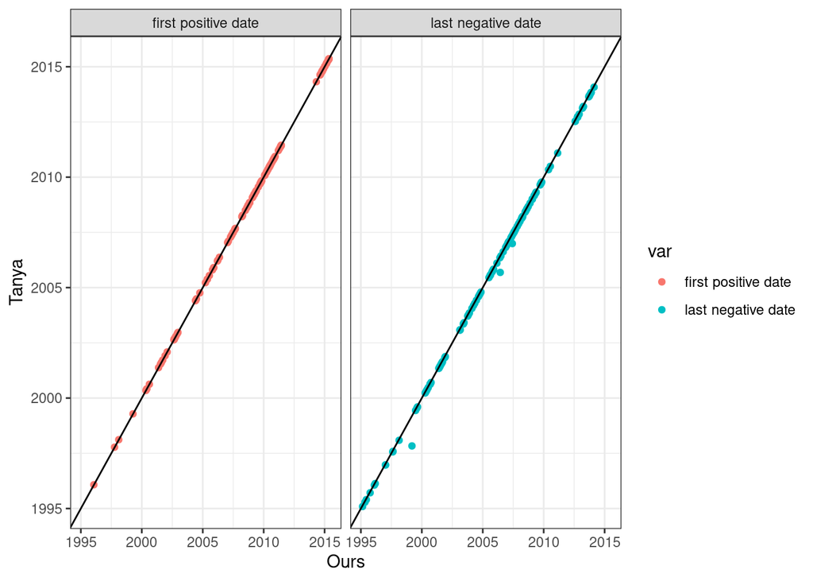

```r
cols <- c('sid', 'est_duration', 'est_duration_min', 'est_duration_max')
dint.tanya <- fread(dintervals.tanya.path, select=cols)

# Translate in terms of dates

cols <- c('est_duration','est_duration_min', 'est_duration_max')
dint.tanya[, (cols):=lapply(.SD, function(x){round(x*365)} ), .SDcols=cols]
dint.tanya <- dint.tanya[, c(.sid2pid.and.date(sid), .SD), .SDcols=cols]
dint.tanya[, (cols):=lapply(.SD, function(x){date-x}), .SDcols=cols]
setnames(dint.tanya, cols, c('midpoint', 'date_first_positive_T', 'date_last_negative_T'))
setnames(dint.tanya, 'date','sample_date')
dint.tanya[, study_id := paste0('RK-', PID)]

cols <- c('study_id', 'date_last_negative', 'date_first_positive')
dint.ours <- dsero[, ..cols]

dint <- merge(dint.tanya, dint.ours, by='study_id')
cols <- grep('date_',value=T, colnames(dint) )
dint[, (cols):=lapply(.SD, as.Date) ,.SDcols=cols]
cols <- c('study_id', cols)
dint <- unique(dint[, ..cols])

# Seroconversion intervals are pretty similar
tmp <- melt(dint, id.vars='study_id')
tmp[, whose:=ifelse(grepl('T$', variable), 'Tanya', 'Ours')]
tmp[, variable:=(gsub('_T$', '', variable))]

tmp1 <- dcast(tmp[variable=='date_first_positive'], study_id ~ variable + whose)
colnames(tmp1) <- gsub('^date.*?ve_','',colnames(tmp1))
tmp1[, var:='first positive date']
tmp2 <- dcast(tmp[variable=='date_last_negative'], study_id ~ variable + whose)
colnames(tmp2) <- gsub('^date.*?ve_','',colnames(tmp2))
tmp2[, var:='last negative date']
tmp <- rbind(tmp1, tmp2)

ggplot(tmp, aes(x=Ours, y=Tanya, col=var)) +
        geom_point() + geom_abline(slope=1) +
        facet_wrap(~var) + theme_bw()
```

## Results

```r
load(path.meta.data)
dsero <- fread(file.seroconverters)

cols <- c('date_last_negative', 'date_first_positive')
new_cols <- c('knownTSI_max', 'knownTSI_min')
dsero[, (new_cols) := lapply(.SD , function(x) (visit_dt - x)/365), .SDcols=cols ]

if(0)
{
        dsero[!is.na(knownTSI_max) & !is.na(knownTSI_min), mean(knownTSI_max - knownTSI_min > 5)]
        png("dserohist.png")
        hist(dsero[, knownTSI_max - knownTSI_min])
        dev.off()
}
```

### Data Sent by Tanya

```r
g0 <- plot.sero.predictions(dtsi.tanya, title="Tanya's analysis")
```

```
## 151  datapoints plotted
```

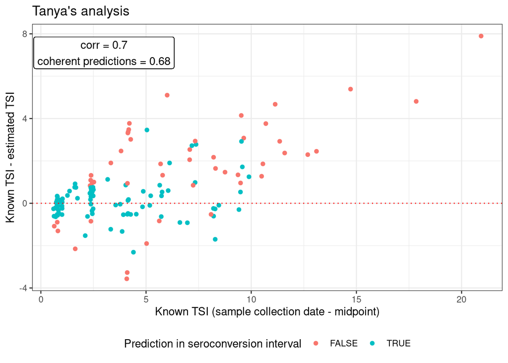

```r
g0
```

```r
h <- show.corrs(dtsi.tanya, title="Tanya's analysis")
```

```
## 151  datapoints plotted
```

### Second Run

```r
g <- plot.sero.predictions(dsero, title='Second analysis')
```

```
## 198  datapoints plotted
```

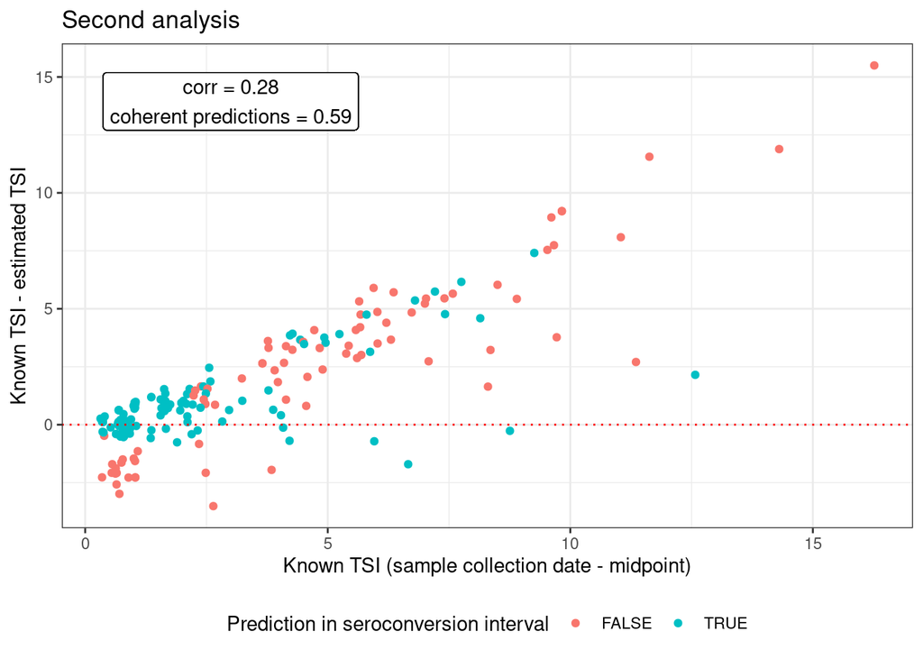

```r
g
```

```r
h <- show.corrs(dsero, title="Second analysis")
```

```
## 198  datapoints plotted
```

### Third Run on few seroconverters

```
## 18  datapoints plotted
```

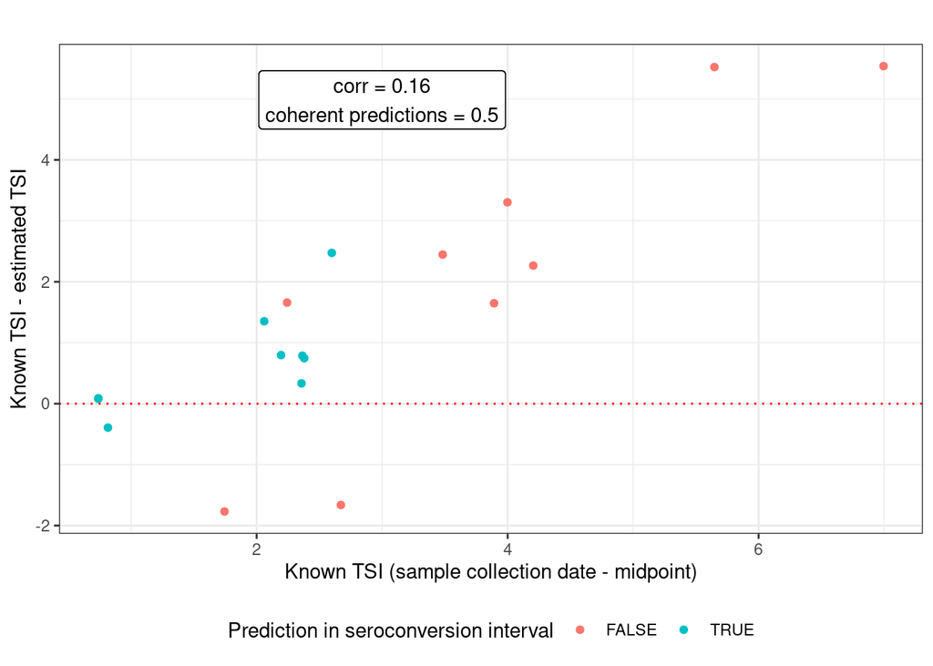

```r
dtsi.sero <- fread(dtsi.2.path, drop='V1')
# str(dtsi.sero)
dtsi.sero[, study_id:=.aid2studyid(RENAME_ID, with_fq=TRUE),]
dtsi.sero <- merge(dtsi.sero, tmp, by='study_id')
dtsi.sero <- unique(dtsi.sero)
# dtsi.sero
plot.sero.predictions(dtsi.sero)
```

```r
g <- plot.sero.predictions(dtsi.sero, title='Second analysis')
```

```
## 18  datapoints plotted
```

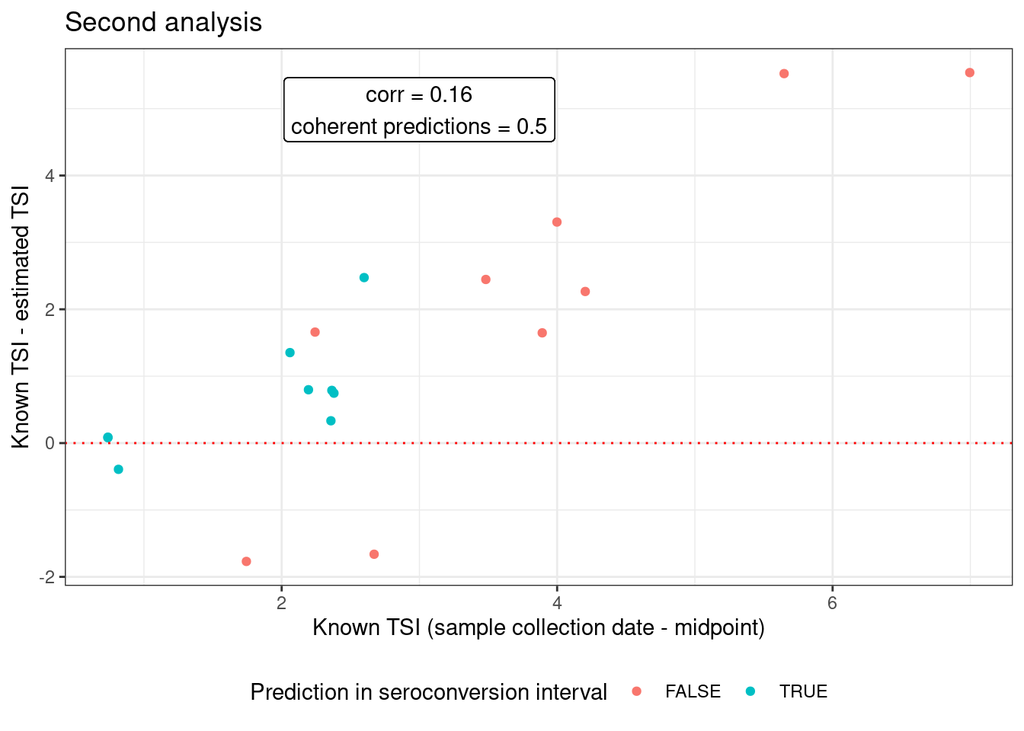

```r
g
```

```r
h <- show.corrs(dsero, title="Second analysis")
```

```
## 198  datapoints plotted
```

```r
cols <- c('study_id','RF_pred_linear')
merge(dtsi.sero[, ..cols], dtsi.tanya[, ..cols], by='study_id')
```

```
##      study_id RF_pred_linear.x RF_pred_linear.y
## 1: RK-A003917        0.6501328        0.9751809
## 2: RK-A045919        0.6579960        0.6786890
```

### Fourth run on more seroconverters

TODO: need better documentation on changes… Here we used Lele’s specifications for `IQTREE` using different reference sequences and `?`. The results are reported in the `seroconverters2` directory.

```
## 149  datapoints plotted
```

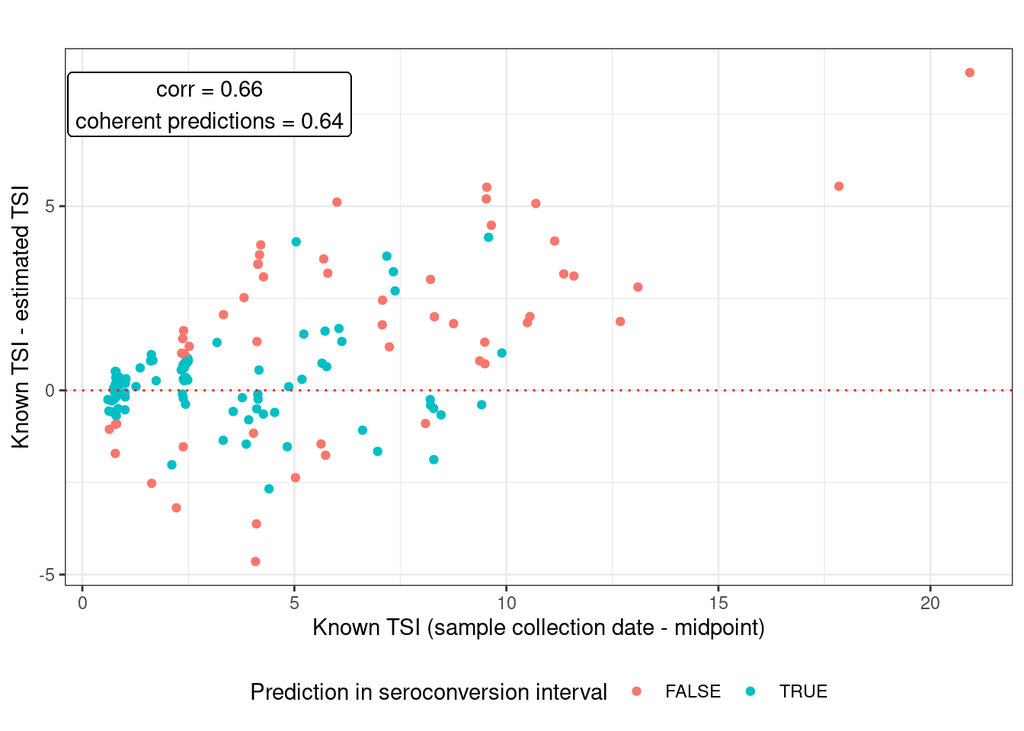

```r
dtsi.sero2 <- fread(dtsi.3.path, drop='V1')
dtsi.sero2[, study_id:=.aid2studyid(RENAME_ID, with_fq=TRUE),]
dtsi.sero2 <- merge(dtsi.sero2, tmp, by='study_id')
dtsi.sero2 <- unique(dtsi.sero2)
plot.sero.predictions(dtsi.sero2)
```

```r
g1 <- plot.sero.predictions(dtsi.sero2, title='Latest analysis')
```

```
## 149  datapoints plotted
```

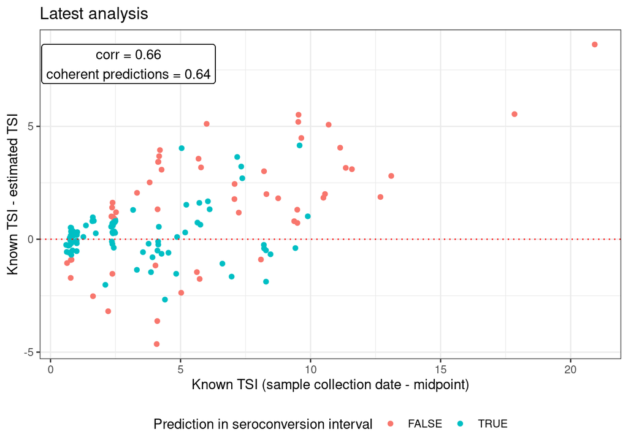

```r
g1
```

```r
h <- show.corrs(dsero, title="Latest analysis")
```

```
## 198  datapoints plotted
```

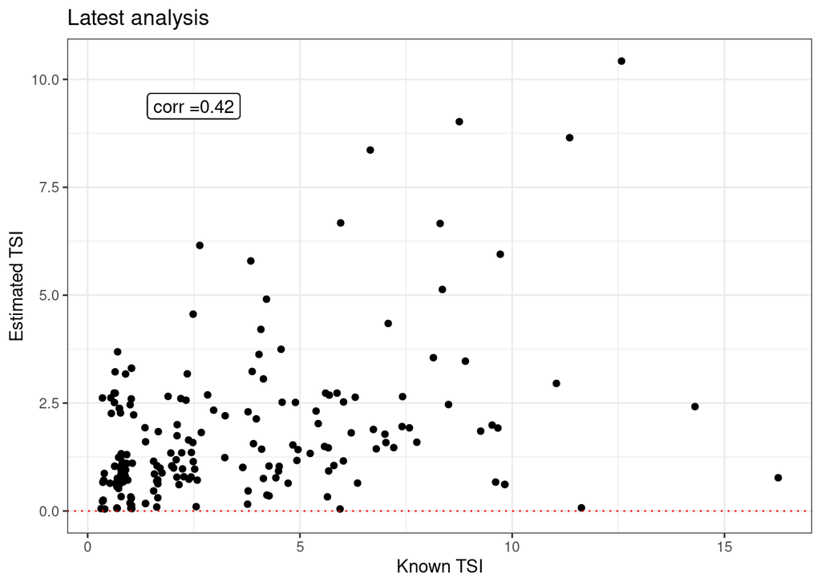

```r
h
```

```r
cols <- c('study_id','RF_pred_linear')
merge(dtsi.sero2[, ..cols], dtsi.tanya[, ..cols], by='study_id')
```

```
##        study_id RF_pred_linear.x RF_pred_linear.y
##   1: RK-A001763        1.7007287        1.6730976
##   2: RK-A003917        0.9928126        0.9751809
##   3: RK-A020112        3.6135735        3.9873597
##   4: RK-A021939        6.3035854        6.6577890
##   5: RK-A025387        8.6192767        7.8838658
##  ---
## 171: RK-K061312        4.6769756        4.5481195
## 172: RK-K066147        0.9775991        0.9353171
## 173: RK-K066202        1.4888792        1.3650464
## 174: RK-K066707        1.3413646        1.3007610
## 175: RK-K109438        0.7525032        0.7870040
```

```r
G <- ggpubr::ggarrange(g0, g1, ncol=2, common.legend=TRUE)
ggsave('comparison_tanya_latest.png',G, w=14, h=10)
```

## Input-Output comparison with Tanya’s run

We also compared the input and output’s of `HIV-phylo-TSI` for our run, and for the run sent by Tanya. The objective was to see whether the predictions are similar, and whether the outputs of the different phyloscanner runs are consistent.

We see that we had some problems with the first run, but then most of these were solved. Still we are counting fewer tips across the 3 genes as compared to Tanya. This is probably due to our phyloscanner parameters, which exclude some tips based on QUALITY?

Also lrtt are not exactly identical but that may make sense: tent to underestimate gag, overestimate pol, and about right for gp120.

### Second run

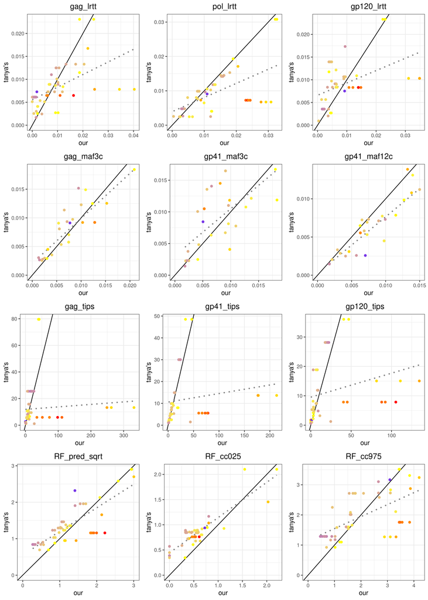

### Fourth run

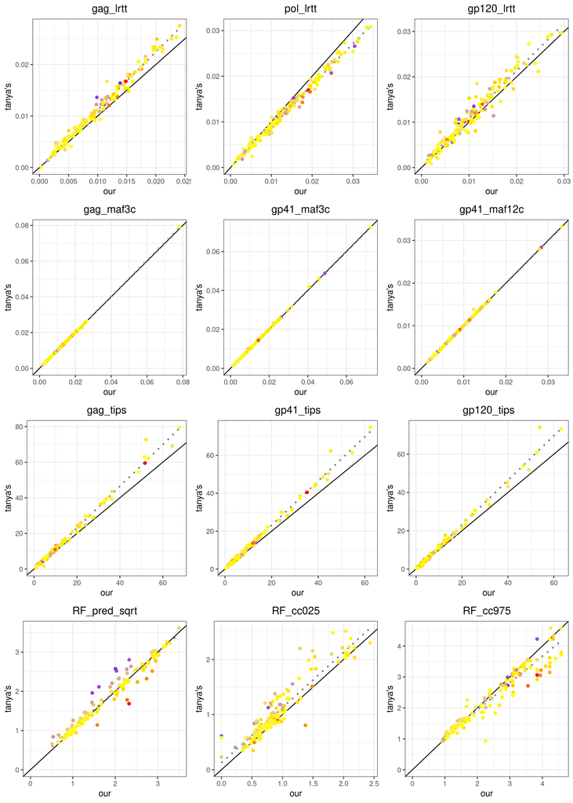